# Victor’s Analysis

```r
here::i_am("gc2/victor.qmd")

library(conflicted)
library(geoR)
library(here)
library(spBayes)
library(tidyverse)
conflicts_prefer(dplyr::filter, dplyr::lag)

data <- read_csv(here("data/processed/annual_bat_counts.csv"))

theme_set(theme_bw())

set.seed(1)
```

# 1 Preparation of the Data for Model-Building

There’s one record for each pair of `AcousticSite` and `Year`.

```r
data %>% count(AcousticSite, Year) %>% filter(n > 1)
```

```
# A tibble: 0 × 3
# ℹ 3 variables: AcousticSite <chr>, Year <dbl>, n <int>
```

Most sites only have data for a single year.

```r
data %>%
    count(AcousticSite, name = "num_years") %>%
    count(num_years, name = "num_sites")
```

```
# A tibble: 3 × 2
  num_years num_sites
      <int>     <int>
1         1       197
2         2        59
3         3        17
```

Below is another summary that shows that most sites only have data for one year.

```r
data %>%
    group_by(AcousticSite) %>%
    summarize(years = str_c(Year, collapse = ",")) %>%
    count(years, sort = TRUE, name = "num_sites")
```

```
# A tibble: 16 × 2
   years          num_sites
   <chr>              <int>
 1 2012                  52
 2 2014                  45
 3 2011,2012             32
 4 2011                  28
 5 2013                  27
 6 2018                  18
 7 2010,2011             15
 8 2017                  12
 9 2010,2011,2012        10
10 2011,2012,2013         7
11 2012,2013              7
12 2016                   6
13 2015                   5
14 2010                   4
15 2015,2016              4
16 2010,2012              1
```

More sites have data for 2012 than for any other year.

```r
count(data, Year, sort = TRUE, name = "num_sites")
```

```
# A tibble: 9 × 2
   Year num_sites
  <dbl>     <int>
1  2012       109
2  2011        92
3  2014        45
4  2013        41
5  2010        30
6  2018        18
7  2017        12
8  2016        10
9  2015         9
```

For each site-year pair, we count the number of species that could be detected at the site in the year.

```r
num_detectable_species <- data %>%
    select(ends_with("_meta")) %>%
    apply(1, function(r) sum(r == "yes"))
```

We create a dataset that we can fit models to. There is one record for each site-year pair. The response is `ALL`, the number of detections across all species. `Lat` and `Long` will be used as spatial covariates. We will use `dist_to_water`, the number of nights on which the detectors were operational, and the number of detectable species as non-spatial covariates.

```r
data_for_mods <- data %>%
    select(
        AcousticSite, Year,
        ALL,
        Lat, Long,
        dist_to_water, starts_with("nights_")
    ) %>%
    pivot_longer(
        starts_with("nights_"),
        names_to = "num_nights_year", names_prefix = "nights_",
        values_to = "num_nights"
    ) %>%
    filter(Year == num_nights_year) %>%
    select(!num_nights_year) %>%
    add_column(num_detectable_species)
```

# 2 Models without Spatial Random Effects

## 2.1 A Poisson Regression Model

We first fit a Poisson regression model without overdispersion or underdispersion. Under the model, at any location $s$,
$$Y(s) \sim \text{Poisson}(\exp\{\beta_0 + X(s)^{\top}\beta\}),
\tag{1}$$
where $X(s)$ is the vector whose components are the distance from $s$ to the shore, the number of operational nights, and the number of detectable species.

```r
mod1 <- glm(
    ALL ~ dist_to_water + num_nights + num_detectable_species,
    poisson,
    data_for_mods
)
mod1_fitted_vals_resids <- tibble(
    fitted_val = fitted(mod1), resid = resid(mod1)
)
```

Below is a summary of the fitted model.

```r
summary(mod1)
```

```
Call:
glm(formula = ALL ~ dist_to_water + num_nights + num_detectable_species,
    family = poisson, data = data_for_mods)

Coefficients:
                         Estimate Std. Error z value Pr(>|z|)
(Intercept)             6.827e+00  6.192e-03  1102.5   <2e-16 ***
dist_to_water          -4.843e-04  7.745e-07  -625.3   <2e-16 ***
num_nights              1.217e-02  1.261e-05   965.7   <2e-16 ***
num_detectable_species  1.217e-01  7.886e-04   154.3   <2e-16 ***
---
Signif. codes:  0 '***' 0.001 '**' 0.01 '*' 0.05 '.' 0.1 ' ' 1

(Dispersion parameter for poisson family taken to be 1)

    Null deviance: 3961690  on 365  degrees of freedom
Residual deviance: 2102221  on 362  degrees of freedom
AIC: 2105505

Number of Fisher Scoring iterations: 6
```

Under the model in Equation 1, $\mathbb{E}(Y(s)) = \text{Var}(Y(s))$, or $\sqrt{\mathbb{E}(Y(s))} = \text{SD}(Y(s))$. We use the residuals to check whether this property of the model is reasonable. For the $i$th observation, which was recorded at location $s_i$, we compare $\sqrt{\widehat{\mathbb{E}}(Y(s_i))}$ to the absolute residual $|Y(s_i) - \widehat{Y}(s_i)|$; if the property is reasonable, then these two quantities should be similar. Below, we plot the absolute residual versus the square root of the fitted value. The two are equal along the dashed line. For some observations, the absolute residual is much larger than expected. However, this isn’t true systematically, so those observations may just be outliers. The absolute residuals that aren’t close to the line seem to be below it more often than above it, which suggests underdispersion.

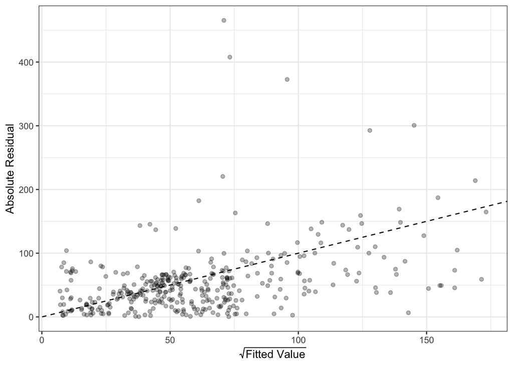

```r
mod1_fitted_vals_resids %>%
    ggplot(aes(sqrt(fitted_val), abs(resid))) +
    geom_point(alpha = 0.3) +
    geom_abline(linetype = "dashed", slope = 1, intercept = 0) +
    labs(x = expression(sqrt("Fitted Value")), y = "Absolute Residual") +
    theme_bw()
```

Below is a histogram of the ratios of the absolute residual to the square root of the fitted value; the dashed line is at one. The histogram reiterates the messages of the scatterplot above.

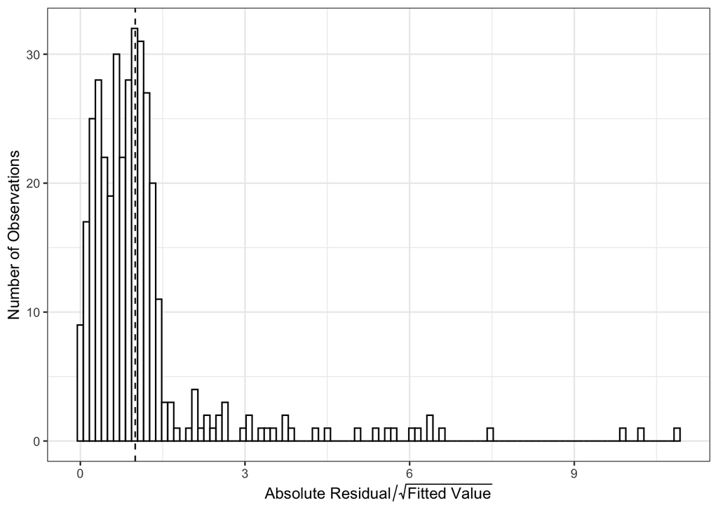

```r
mod1_fitted_vals_resids %>%
    mutate(ratio = abs(resid) / sqrt(fitted_val)) %>%
    ggplot(aes(ratio)) +
    geom_histogram(bins = 100, color = "black", fill = "white") +
    geom_vline(linetype = "dashed", xintercept = 1) +
    labs(
        x = expression("Absolute Residual" / sqrt("Fitted Value")),
        y = "Number of Observations"
    )
```

Below is a function for computing the Pearson dispersion statistic.

```r
calc_pearson_disperse_stat <- function(mod) {
    sum(resid(mod)^2 / fitted(mod)) / df.residual(mod)
}
```

The Pearson dispersion statistic for the model in Equation 1 is below.

```r
calc_pearson_disperse_stat(mod1)
```

```
[1] 3.198157
```

To continue assessing the fit of the model, we generate 100 samples of counts under the model. We will compare how the counts in these samples are distributed to how the real counts are distributed.

```r
samples <- replicate(
    100,
    rpois(nrow(data_for_mods), mod1_fitted_vals_resids$fitted_val)
) %>%
    `colnames<-`(str_c("sample", 1:100)) %>%
    as_tibble() %>%
    pivot_longer(
        everything(),
        names_to = "sample", names_prefix = "sample",
        values_to = "ALL"
    ) %>%
    bind_rows(tibble(sample = "0", ALL = data_for_mods$ALL), .)
```

In the plot below, there is one density estimate for each sample (the gray curves) as well as a density estimate for the real data (the blue curve). The tails look fairly similar, but the blue curve’s peak is to the left of the gray curves’ peaks. This suggests that the count under the model in Equation 1 tends to be somewhat larger than it should be.

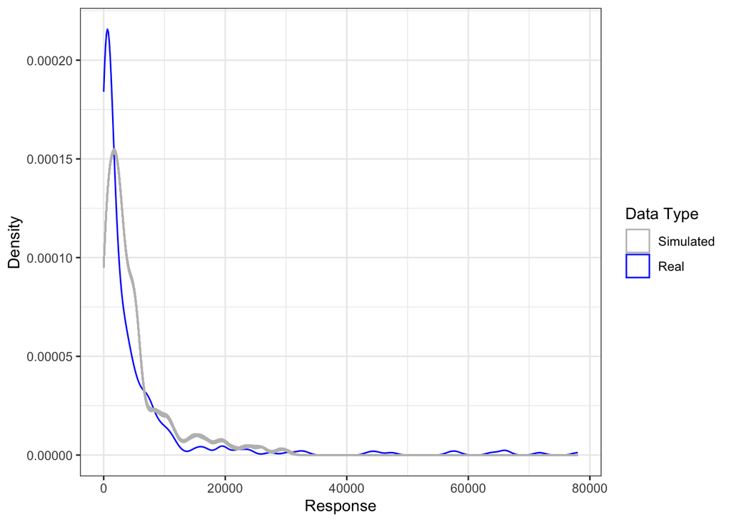

```r
samples %>%
    mutate(is_real_data = sample == "0") %>%
    ggplot(aes(ALL, group = sample, color = is_real_data)) +
    scale_color_manual(
        labels = c(`TRUE` = "Real", `FALSE` = "Simulated"),
        values = c(`TRUE` = "blue", `FALSE` = "gray")
    ) +
    geom_density() +
    labs(x = "Response", y = "Density", color = "Data Type")
```

We next compute the empirical semivariogram of the residuals from the model in Equation 1. Since there are replicates for some sites, we need to jitter the coordinates to make things work. We use 100 bins to compute the empirical semivariogram.

```r
mod1_variogram <- bind_cols(data_for_mods, mod1_fitted_vals_resids) %>%
    select("Long", "Lat", "resid") %>%
    as.geodata() %>%
    jitterDupCoords(max = 1e-4) %>%
    variog(uvec = 100, messages = FALSE)
```

The empirical semivariogram suggests spatial dependence only over small distances. We can try fitting a Poisson regression model with spatial random effects.

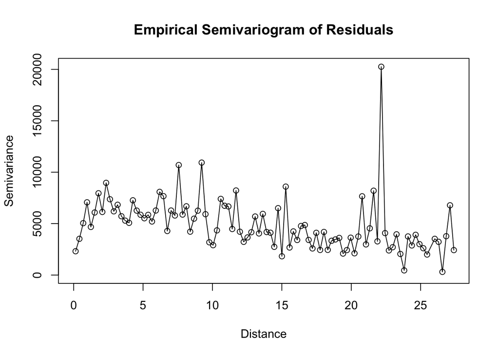

```r
mod1_variogram %>%
    plot(
        type = "o",
        main = "Empirical Semivariogram of Residuals",
        xlab = "Distance", ylab = "Semivariance"
    )
```

## 2.2 A Quasi-Poisson Regression Model

We next try a Quasi-Poisson regression model, i.e., one for which the dispersion parameter is estimated instead of being fixed at one.

```r
mod2 <- glm(
    ALL ~ dist_to_water + num_nights + num_detectable_species,
    quasipoisson,
    data_for_mods
)
mod2_fitted_vals_resids <- tibble(
    fitted_val = fitted(mod2), resid = resid(mod2)
)
```

Below is a summary of the fitted model. Note that the estimated dispersion parameter is large, so the fitted model is similar to the first fitted model.

```r
summary(mod2)
```

```
Call:
glm(formula = ALL ~ dist_to_water + num_nights + num_detectable_species,
    family = quasipoisson, data = data_for_mods)

Coefficients:
                         Estimate Std. Error t value Pr(>|t|)
(Intercept)             6.827e+00  6.103e-01  11.186  < 2e-16 ***
dist_to_water          -4.843e-04  7.634e-05  -6.344 6.69e-10 ***
num_nights              1.217e-02  1.242e-03   9.798  < 2e-16 ***
num_detectable_species  1.217e-01  7.772e-02   1.566    0.118
---
Signif. codes:  0 '***' 0.001 '**' 0.01 '*' 0.05 '.' 0.1 ' ' 1

(Dispersion parameter for quasipoisson family taken to be 9714.141)

    Null deviance: 3961690  on 365  degrees of freedom
Residual deviance: 2102221  on 362  degrees of freedom
AIC: NA

Number of Fisher Scoring iterations: 6
```

Since the dispersion parameter estimate is large, the scatterplot of the absolute residual versus the square root of the fitted value looks almost exactly like the first scatterplot.

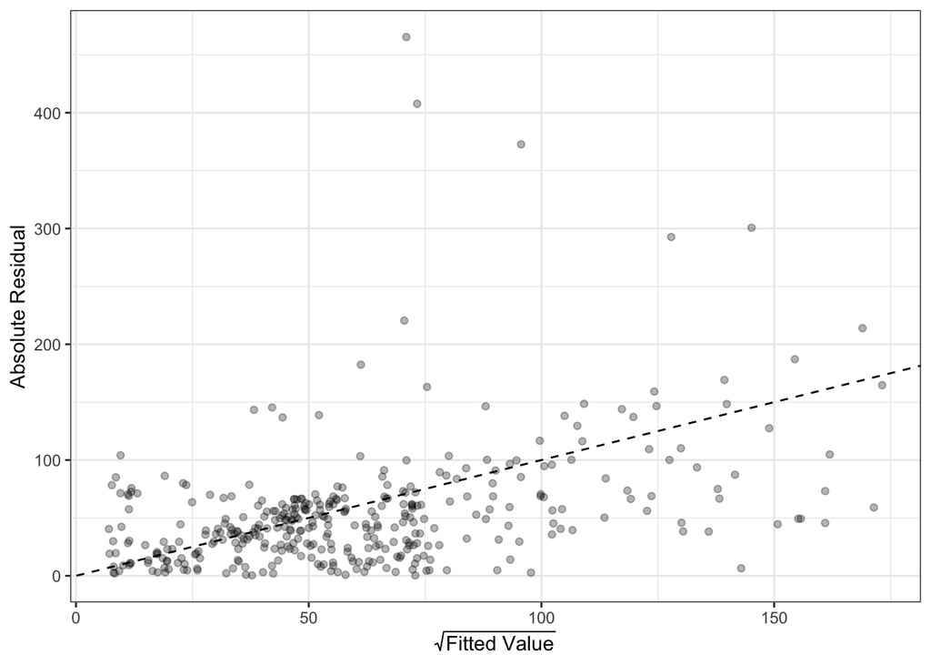

```r
mod2_fitted_vals_resids %>%
    ggplot(aes(sqrt(fitted_val), abs(resid))) +
    geom_point(alpha = 0.3) +
    geom_abline(linetype = "dashed", slope = 1, intercept = 0) +
    labs(x = expression(sqrt("Fitted Value")), y = "Absolute Residual") +
    theme_bw()
```

The Pearson dispersion statistic didn’t change.

```r
calc_pearson_disperse_stat(mod2)
```

```
[1] 3.198157
```

# 3 A Model with Spatial Random Effects

Since the empirical semivariogram of the residuals for the Poisson regression model suggests spatial dependence over small distances, we next fit a Poisson regression model with spatial random effects.

To avoid numerical issues, we jitter the coordinates of the sites.

```r
jittered_data_for_mods <- mutate(
    data_for_mods,
    Lat = jitter(Lat, factor = 1e-4), Long = jitter(Long, factor = 1e-4)
)
```

We fit a model with an exponential covariance function.

- We use the coefficient vector from the model in Equation 1 as the starting value for $\beta$.
- Since $\sigma^2$ is the variance of a spatial random effect, we use as its starting value the variance of the residuals from the model in Equation 1.
- The starting value for $\phi$ is the reciprocal of the distance at which spatial dependence seems to begin weakening in the empirical semivariogram above.
- Finally, we use zeros as the starting values for the spatial random effects $w$.

Unfortunately, the acceptance rate is close to zero. We’ve tried fiddling with the values of `starting`, `tuning`, and `priors` to increase the acceptance rate, but we haven’t found values that work well yet.

```r
mod1_coefs <- coef(mod1)
mod1_resid_var <- var(resid(mod1))
mod3 <- spGLM(
    ALL ~ dist_to_water + num_nights + num_detectable_species,
    family = "poisson",
    data = jittered_data_for_mods,
    coords = as.matrix(jittered_data_for_mods[c("Lat", "Long")]),
    starting = list(
        beta = mod1_coefs, sigma.sq = mod1_resid_var, phi = 0.5, w = 0
    ),
    tuning = list(
        beta = 0.1 * abs(mod1_coefs),
        sigma.sq = 0.1 * mod1_resid_var,
        phi = 0.001,
        w = 0
    ),
    priors = list(
        sigma.sq.ig = c(2, 3 * mod1_resid_var),
        phi.unif = c(0.1, 1),
        beta.normal = list(mod1_coefs, 0.33 * sqrt(abs(mod1_coefs)))
    ),
    cov.model = "exponential",
    n.samples = 5000,
    verbose = TRUE,
    n.report = 100
)
```

```
----------------------------------------
    General model description
----------------------------------------
Model fit with 366 observations.

Number of covariates 4 (including intercept if specified).

Using the exponential spatial correlation model.

Number of MCMC samples 5000.

Priors and hyperpriors:
    beta normal:
        mu: 6.827   -0.000  0.012   0.122
        sd: 0.862   0.007   0.036   0.115


    sigma.sq IG hyperpriors shape=2.00000 and scale=16929.83376

    phi Unif hyperpriors a=0.10000 and b=1.00000

Metropolis tuning values:
    beta tuning:
    0.683   0.000   0.000   0.000
    0.000   0.000   0.000   0.000
    0.000   0.000   0.001   0.000
    0.000   0.000   0.000   0.012

    sigma.sq tuning: 23.75558

    phi tuning: 0.03162

Metropolis starting values:
    beta starting:
        6.827   -0.000  0.012   0.122

    sigma.sq starting: 5643.27792

    phi starting: 0.50000

```

[output cut: 186 more lines]

```
-------------------------------------------------
Sampled: 4700 of 5000, 94.00%
Report interval Metrop. Acceptance rate: 0.00%
Overall Metrop. Acceptance rate: 0.28%
-------------------------------------------------
Sampled: 4800 of 5000, 96.00%
Report interval Metrop. Acceptance rate: 0.00%
Overall Metrop. Acceptance rate: 0.27%
-------------------------------------------------
Sampled: 4900 of 5000, 98.00%
Report interval Metrop. Acceptance rate: 0.00%
Overall Metrop. Acceptance rate: 0.27%
-------------------------------------------------
Sampled: 5000 of 5000, 100.00%
-------------------------------------------------
```